# Final Project

Connor Lawson and Darrious Barger

5/4/2020

# Model from the previous project

```r
model1 = lm(price ~ garagesize + size + bedrooms + I(bedrooms^2), data = housing)
summary(model1)
```

```
##
## Call:
## lm(formula = price ~ garagesize + size + bedrooms + I(bedrooms^2),
##     data = housing)
##
## Residuals:
##      Min       1Q   Median       3Q      Max
## -116.631  -39.229   -7.227   36.178  167.855
##
## Coefficients:
##               Estimate Std. Error t value Pr(>|t|)
## (Intercept)    316.278    119.070   2.656  0.00975 **
## garagesize      16.965      9.468   1.792  0.07741 .
## size            67.340     32.588   2.066  0.04244 *
## bedrooms       -86.280     60.554  -1.425  0.15858
## I(bedrooms^2)    8.671      7.880   1.100  0.27487
## ---
## Signif. codes:  0 '***' 0.001 '**' 0.01 '*' 0.05 '.' 0.1 ' ' 1
##
## Residual standard error: 55.16 on 71 degrees of freedom
## Multiple R-squared:  0.2087, Adjusted R-squared:  0.1641
## F-statistic: 4.681 on 4 and 71 DF,  p-value: 0.002071
```

Our final model from the last project.

# Using regsubsets on all the data

```r
housing$elem <- as.numeric(c("edison" = 0, "adams" = 1, "parker" = 2, "edge" = 3, "harris" = 4, "crest" = 5)[housing$elem])
housing$status <- as.numeric(c("sld" = 0, "pen" = 1, "act" = 2)[housing$status])
```

We converted the elementry school districts to numeric, so that each individual district is not included as seperate predictor in regsubsets.

```r
fow_sel <- regsubsets(price ~ ., data = housing, nvmax = 11, method = "forward")
```

```
## Reordering variables and trying again:
```

```r
regSum <- summary(fow_sel)
regSum
```

```
## Subset selection object
## Call: regsubsets.formula(price ~ ., data = housing, nvmax = 11, method = "forward")
## 10 Variables  (and intercept)
##                 Forced in Forced out
## id                  FALSE      FALSE
## size                FALSE      FALSE
## lot                 FALSE      FALSE
## bath                FALSE      FALSE
## bedrooms            FALSE      FALSE
## yearbuilt           FALSE      FALSE
## garagesize          FALSE      FALSE
## status              FALSE      FALSE
## elem                FALSE      FALSE
## agestandardized     FALSE      FALSE
## 1 subsets of each size up to 9
## Selection Algorithm: forward
##          id  size lot bath bedrooms yearbuilt agestandardized garagesize status
## 1  ( 1 ) " " " "  " " " "  " "      " "       " "             "*"        " "
## 2  ( 1 ) " " " "  "*" " "  " "      " "       " "             "*"        " "
## 3  ( 1 ) " " " "  "*" "*"  " "      " "       " "             "*"        " "
## 4  ( 1 ) " " " "  "*" "*"  "*"      " "       " "             "*"        " "
## 5  ( 1 ) " " " "  "*" "*"  "*"      " "       " "             "*"        " "
## 6  ( 1 ) " " " "  "*" "*"  "*"      " "       " "             "*"        "*"
## 7  ( 1 ) " " "*"  "*" "*"  "*"      " "       " "             "*"        "*"
## 8  ( 1 ) " " "*"  "*" "*"  "*"      " "       "*"             "*"        "*"
## 9  ( 1 ) "*" "*"  "*" "*"  "*"      " "       "*"             "*"        "*"
##          elem
## 1  ( 1 ) " "
## 2  ( 1 ) " "
## 3  ( 1 ) " "
## 4  ( 1 ) " "
## 5  ( 1 ) "*"
## 6  ( 1 ) "*"
## 7  ( 1 ) "*"
## 8  ( 1 ) "*"
## 9  ( 1 ) "*"
```

We decided to use foward selection to see which predictors would be the best for our model.

```r
regSum$rsq
```

```
## [1] 0.1284406 0.1554528 0.1768114 0.2066046 0.2275819 0.2609790 0.2947050
## [8] 0.3008925 0.3017657
```

```r
regSum$adjr2
```

```
## [1] 0.1166628 0.1323146 0.1425119 0.1619063 0.1724092 0.1967163 0.2221011
## [8] 0.2174169 0.2065519
```

```r
regSum$cp
```

```
## [1] 9.135170 8.620547 8.632234 7.858729 7.905909 6.796912 5.657291 7.081287
## [9] 9.000000
```

```r
regSum$bic
```

```
## [1] -1.7863476  0.1516426  2.5356154  4.0647149  6.3589706  7.3305359  8.1112938
## [8] 11.7723457 16.0080950
```

```r
which.max(regSum$rsq)
```

```
## [1] 9
```

```r
which.max(regSum$adjr2)
```

```
## [1] 7
```

```r
which.min(regSum$cp)
```

```
## [1] 7
```

```r
which.min(regSum$bic)
```

```
## [1] 1
```

We used which.max and which.min to help us pick the best amount of predictors for our model. We decided to go with 7 predictors in our model, because both adjr2 and cp values have 7 predictors as optimal.

```r
coef(fow_sel,7)
```

[output not shown]

```r
model2 <- lm(price ~ size + lot + bath + bedrooms + garagesize + status + elem, data = housing)
summary(model2)
```

```
##
## Call:
## lm(formula = price ~ size + lot + bath + bedrooms + garagesize +
##     status + elem, data = housing)
##
## Residuals:
##    Min     1Q Median     3Q    Max
## -93.09 -38.07  -8.45  39.59 136.76
##
## Coefficients:
##             Estimate Std. Error t value Pr(>|t|)
## (Intercept)  169.072     63.807   2.650   0.0100 *
## size          63.687     35.318   1.803   0.0758 .
## lot            5.721      3.994   1.432   0.1566
## bath          16.834     13.061   1.289   0.2018
## bedrooms     -20.680      9.860  -2.097   0.0397 *
## garagesize     8.484      9.909   0.856   0.3949
## status        16.442      7.731   2.127   0.0371 *
## elem          -9.399      4.618  -2.035   0.0457 *
## ---
## Signif. codes:  0 '***' 0.001 '**' 0.01 '*' 0.05 '.' 0.1 ' ' 1
##
## Residual standard error: 53.21 on 68 degrees of freedom
## Multiple R-squared:  0.2947, Adjusted R-squared:  0.2221
## F-statistic: 4.059 on 7 and 68 DF,  p-value: 0.0009006
```

Created our second model with 7 predictors from our foward selection testing.

# Creating training and test data

```r
set.seed(123)
half <- sample(nrow(housing), nrow(housing) * 0.5, replace = FALSE)
train <- housing[half, ]
test <- housing[-half, ]
```

Spilt our data in half to make the training and test data.

# Using regsubsets on the training data

```r
test.mat <- model.matrix(price ~ ., data = test)
```

Created a design matrix by expanding factors to a set of dummy variables.

```r
regfit.best <- regsubsets(price ~ ., data = train, nvmax = 11, method = "forward")
```

```
## Reordering variables and trying again:
```

```r
summary(regfit.best)
```

```
## Subset selection object
## Call: regsubsets.formula(price ~ ., data = train, nvmax = 11, method = "forward")
## 10 Variables  (and intercept)
##                 Forced in Forced out
## id                  FALSE      FALSE
## size                FALSE      FALSE
## lot                 FALSE      FALSE
## bath                FALSE      FALSE
## bedrooms            FALSE      FALSE
## yearbuilt           FALSE      FALSE
## garagesize          FALSE      FALSE
## status              FALSE      FALSE
## elem                FALSE      FALSE
## agestandardized     FALSE      FALSE
## 1 subsets of each size up to 9
## Selection Algorithm: forward
##          id  size lot bath bedrooms yearbuilt agestandardized garagesize status
## 1  ( 1 ) " " " "  " " " "  " "      " "       " "             "*"        " "
## 2  ( 1 ) " " " "  "*" " "  " "      " "       " "             "*"        " "
## 3  ( 1 ) " " " "  "*" " "  " "      " "       " "             "*"        " "
## 4  ( 1 ) " " " "  "*" " "  "*"      " "       " "             "*"        " "
## 5  ( 1 ) " " "*"  "*" " "  "*"      " "       " "             "*"        " "
## 6  ( 1 ) "*" "*"  "*" " "  "*"      " "       " "             "*"        " "
## 7  ( 1 ) "*" "*"  "*" " "  "*"      "*"       " "             "*"        " "
## 8  ( 1 ) "*" "*"  "*" " "  "*"      "*"       " "             "*"        "*"
## 9  ( 1 ) "*" "*"  "*" "*"  "*"      "*"       " "             "*"        "*"
##          elem
## 1  ( 1 ) " "
## 2  ( 1 ) " "
## 3  ( 1 ) "*"
## 4  ( 1 ) "*"
## 5  ( 1 ) "*"
## 6  ( 1 ) "*"
## 7  ( 1 ) "*"
## 8  ( 1 ) "*"
## 9  ( 1 ) "*"
```

Used regsubsets on the training data to find the best model.

```r
val.errors <- rep(NA, 11)
```

Vector used to keep track of the validation errors for the model.

```r
for (i in 1:9)
{
  coefi=coef(regfit.best,id=i)
  pred=test.mat[,names(coefi)]%*%coefi
  val.errors[i] <- mean((test$price-pred)^2)
}
val.errors
```

```
##  [1] 3942.035 4069.565 4176.020 4230.043 3709.728 4746.661 4746.661 4407.895
##  [9] 4304.288       NA       NA
```

For looop is used to calculate the MSE values for the different predictions from each of the models.

```r
which.min(val.errors)
```

```
## [1] 5
```

Used which.min to find the model with the smallest validation error.

```r
regfit.best2 <- regsubsets(price ~ ., data = train, nvmax = 4, method = "forward")
```

```
## Reordering variables and trying again:
```

```r
summary(regfit.best2)
```

[output not shown]

After running resubsets it was decided that a model using 5 predictors will be the best.

```r
model3 <- lm(price ~ size + lot + bedrooms + elem + garagesize, data = housing )
summary(model3)
```

```
##
## Call:
## lm(formula = price ~ size + lot + bedrooms + elem + garagesize,
##     data = housing)
##
## Residuals:
##      Min       1Q   Median       3Q      Max
## -114.152  -42.707   -4.683   42.951  143.333
##
## Coefficients:
##             Estimate Std. Error t value Pr(>|t|)
## (Intercept)  190.792     64.349   2.965  0.00414 **
## size          66.795     32.529   2.053  0.04377 *
## lot            4.568      4.006   1.140  0.25804
## bedrooms     -19.489     10.105  -1.929  0.05784 .
## elem          -5.437      4.469  -1.217  0.22787
## garagesize    16.897      9.601   1.760  0.08280 .
## ---
## Signif. codes:  0 '***' 0.001 '**' 0.01 '*' 0.05 '.' 0.1 ' ' 1
##
## Residual standard error: 54.81 on 70 degrees of freedom
## Multiple R-squared:  0.2297, Adjusted R-squared:  0.1747
## F-statistic: 4.175 on 5 and 70 DF,  p-value: 0.002234
```

# Using Ridge Regression

```r
set.seed(123)
x=model.matrix(price ~ ., data = train)[,-1]
y=train$price
```

Below, we are setting up the lamba values that we will test. We are also using the `glmnet()` function to fit the ridge regression.

```r
set.seed(123)
grid=10^seq(10,-2,length=100)
ridge.mod=glmnet(x,y,alpha=0,lambda=grid)
```

This finds the value of lambda at the 50th iteration of the sequence

```r
ridge.mod$lambda[50]
```

```
## [1] 11497.57
```

```r
coef(ridge.mod)[,50]
```

```
##     (Intercept)              id            size             lot            bath
##   297.934449939    -0.001163783     0.239519700     0.052833461     0.020230982
##        bedrooms       yearbuilt agestandardized      garagesize          status
##    -0.152980459     0.001385527     0.013855274     0.177937176     0.009851847
##            elem
##    -0.016462209
```

This will calculate the sum of squared betas in the ridge regression model.

```r
sqrt(sum(coef(ridge.mod)[-1,50]^2))
```

```
## [1] 0.3408787
```

The predict function will give us the ridge regression coefficients for lamba = 50.

```r
predict(ridge.mod,s=50,type="coefficients")
```

```
## 11 x 1 sparse Matrix of class "dgCMatrix"
##                             1
## (Intercept)     274.450205080
## id               -0.184442526
## size             33.348068602
## lot               4.443568362
## bath              1.435382909
## bedrooms        -14.581679322
## yearbuilt        -0.009042219
## agestandardized  -0.089577048
## garagesize       15.176780725
## status           -1.286406816
## elem             -3.077596431
```

```r
set.seed(1)
train=sample(1:nrow(x), nrow(x)/2)
test=(-train)
y.test=y[test]

ridge.mod=glmnet(x[train,],y[train],alpha=0,lambda=grid, thresh=1e-12)
ridge.pred=predict(ridge.mod,s=4,newx=x[test,])
```

# Partial Least Squares Regression

```r
set.seed(123)
pls.fit=plsr(price ~ .,data = housing, subset = train, scale=TRUE, validation="CV")
summary(pls.fit)
```

[output not shown]

Fiiting the pls model using the training data and using cross validation to determine the number of components needed.

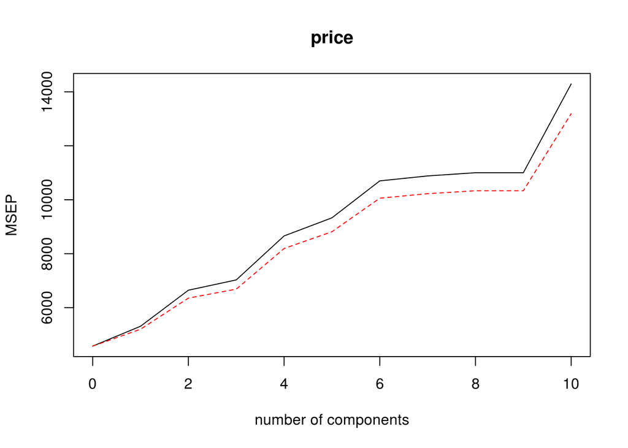

```r
validationplot(pls.fit,val.type="MSEP")
```

```r
pls.pred = predict(pls.fit, newx = x[train,], ncomp = 1)
pls.fit = plsr(price ~ ., data = housing,scale=TRUE,ncomp = 1)
```

# Calculate the MSE

MSE For model 1

```r
mean((housing$price - predict(model1, housing))^2)
```

```
## [1] 2842.535
```

MSE for model 2

```r
mean((housing$price - predict(model2, housing))^2)
```

```
## [1] 2533.517
```

MSE for model 3

```r
mean((housing$price - predict(model3, housing))^2)
```

```
## [1] 2767.005
```

MSE for model 4

```r
mean((ridge.pred-y.test)^2)
```

```
## [1] 3351.677
```

MSE for model 5

```r
mean((pls.pred-y.test)^2)
```

```
## [1] 4597.93
```

After calculating all of the MSE values for the models, model 2 seems to be the most prefered model out if the group. This is due to it having the lowest MSE value of 2533.517.